# 21 - Data Processing

STAT 107 - NBA Statistical Analysis Project

**What this file does.** It loads the cleaned data from `12_DataSaving.RData` and applies the inclusion rule (at least 20 games played), creates a new variable for the analysis, and saves the result to `22_DataSaving.RData`.

## 1. Load packages, functions, and cleaned data

```r
source("R/00_requirements.R")
source("02_funct_DataProcessing.R")
load("12_DataSaving.RData")
dim(nba_clean)
```

```
## [1] 569  12
```

## 2. Inclusion rule: at least 20 games played

Our response variable is **points per game**, an average. The histogram shows how many players appeared in only a few games:

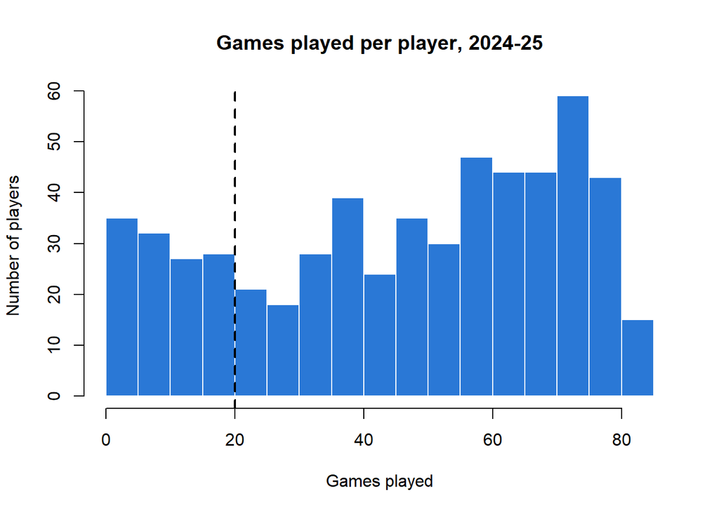

```r
hist(nba_clean$games, breaks = 20, main = "Games played per player, 2024-25",
     xlab = "Games played", ylab = "Number of players",
     col = "#2a78d6", border = "white")
abline(v = 20, lty = 2, lwd = 2)
```

```r
sum(nba_clean$games < 20)
```

```
## [1] 113
```

We keep players with **at least 20 games**, about one quarter of the 82-game season.

### Does the cutoff change the comparison?

Before committing to 20 games, we compare the mean points per game by position under four different cutoffs, using a `for` loop.

```r
cutoffs <- c(1, 10, 20, 41)
for (k in cutoffs) {
  players_kept <- nba_clean[nba_clean$games >= k, ]
  print(paste("At least", k, "games:", nrow(players_kept), "players"))
  print(mean_by_position(players_kept$pts, players_kept$pos))
}
```

```
## [1] "At least 1 games: 569 players"
##  PG  SG  SF  PF   C
## 9.8 8.9 8.4 8.9 8.5
## [1] "At least 10 games: 508 players"
##   PG   SG   SF   PF    C
## 10.6  9.5  9.4  9.6  8.9
## [1] "At least 20 games: 456 players"
##   PG   SG   SF   PF    C
## 10.9 10.1 10.3 10.0  9.3
## [1] "At least 41 games: 341 players"
##   PG   SG   SF   PF    C
## 12.6 11.2 11.3 11.2 10.6
```

### Apply the filter

```r
min_games <- 20
nba_model <- filter_min_games(nba_clean, min_games)
```

[output not shown]

```r
table(nba_model$pos)
```

```
##
##  PG  SG  SF  PF   C
##  85 123  76  86  86
```

After the filter, 456 players remain, and every position still has more than 75 players, enough to compare groups.

## 3. Create a new variable: points per 36 minutes

Points per game mixes two things: how often a player scores, and how long he plays. **Points per 36 minutes** removes the playing-time part.

```r
nba_model$pts_per36 <- per36(nba_model$pts, nba_model$minutes)
summary(nba_model$pts_per36)
```

```
##    Min. 1st Qu.  Median    Mean 3rd Qu.    Max.
##   5.143  12.240  15.091  15.746  18.688  34.421
```

## 4. Save the processed data

```r
save(nba_clean, nba_model, min_games, file = "22_DataSaving.RData")
```